# Sesión 2: Model Lineal General, caso IMDb (2)

MLGz

25 de septiembre de 2018

# IMDb data

El conjunto de datos contiene información de 322 películas de cine de USA de la última década. Los datos se han recogido de la web www.imdb.com e incluyen la siguiente información:

- movie_title: Título de la película
- gross: Recaudación total (millones de $)
- budget: Presupuesto (millones de $)
- duration: Duración (minutos)
- title_year: Año de estreno
- actor1_fl: Popularidad del primer actor (número de “Likes” en Facebook)
- actor2_fl: Popularidad del segundo actor (número de “Likes” en Facebook)
- actor3_fl: Popularidad del tercer actor (número de “Likes” en Facebook)
- cast_fl: Popularidad total del casting (número de “Likes” en Facebook)
- faces_poster: Número de caras que aparecen en el póster
- Genre: Género de la película (Comedy, Drama, Action, Horror)

Se pretende explorar las relaciones entre las variables recogidas y la recaudación de la película.

A partir del modelo obtenido mediante mecanismo stepwise, explora la extensón del modelo:

1. Corrige la multicolinealidad eliminando alguna de las variables que están altamente correlacionadas (*actor_fl* y *cast_fl*)
2. Verifica la significación de la variable *faces_poster* si eliminamos la observación más extrema (leverage muy alto)
3. Comprueba si es mejor incluir un término cuadrático en *lnbudget* o categorizar la variable
4. Comprueba si es mejor incluir transformar la variable *cast_fl* con logaritmos, añadir un término cuadrático o categorizar la variable.

```r
data=read.csv2("IMDb.csv")
summary(data)
```

```
##             movie_title      gross               budget
##  12 Years a Slave :  1   Min.   :  2694973   Min.   :   700000
##  1408             :  1   1st Qu.: 33421866   1st Qu.: 20000000
##  2012             :  1   Median : 63590421   Median : 40000000
##  21 & Over        :  1   Mean   : 96911533   Mean   : 66710559
##  27 Dresses       :  1   3rd Qu.:126948102   3rd Qu.: 90000000
##  30 Days of Night :  1   Max.   :760505847   Max.   :300000000
##  (Other)          :316
##     duration     title_year    director_fl         actor1_fl
##  Min.   : 80   Min.   :2006   Min.   :    0.00   Min.   :  129.0
##  1st Qu.:101   1st Qu.:2008   1st Qu.:   19.25   1st Qu.:  989.5
##  Median :112   Median :2011   Median :   98.00   Median :11000.0
##  Mean   :116   Mean   :2011   Mean   : 1173.80   Mean   :11069.4
##  3rd Qu.:128   3rd Qu.:2013   3rd Qu.:  301.00   3rd Qu.:16750.0
##  Max.   :195   Max.   :2016   Max.   :21000.00   Max.   :49000.0
##
##    actor2_fl       actor3_fl          cast_fl       faces_poster
##  Min.   :    4   Min.   :    0.0   Min.   :  214   Min.   : 0.000
##  1st Qu.:  564   1st Qu.:  309.2   1st Qu.: 3196   1st Qu.: 0.000
##  Median :  893   Median :  585.5   Median :13316   Median : 1.000
##  Mean   : 3443   Mean   : 1410.8   Mean   :17405   Mean   : 1.543
##  3rd Qu.: 3000   3rd Qu.:  916.8   3rd Qu.:25255   3rd Qu.: 2.000
##  Max.   :25000   Max.   :19000.0   Max.   :92000   Max.   :31.000
##
##     Genre
##  Action: 74
##  Comedy:101
##  Drama : 99
##  Horror: 48
##
##
##
```

```r
row.names(data)=data[,1]
data=data[,-1]
head(data)
```

```
##                                               gross    budget duration
## Avatar                                    760505847 237000000      178
## Pirates of the Caribbean: At World's End  309404152 300000000      169
## John Carter                                73058679 263700000      132
## Spider-Man 3                              336530303 258000000      156
## Avengers: Age of Ultron                   458991599 250000000      141
## Batman v Superman: Dawn of Justice        330249062 250000000      183
##                                           title_year director_fl actor1_fl
## Avatar                                          2009           0      1000
## Pirates of the Caribbean: At World's End        2007         563     40000
## John Carter                                     2012         475       640
## Spider-Man 3                                    2007           0     24000
## Avengers: Age of Ultron                         2015           0     26000
## Batman v Superman: Dawn of Justice              2016           0     15000
##                                           actor2_fl actor3_fl cast_fl
## Avatar                                          936       855    4834
## Pirates of the Caribbean: At World's End       5000      1000   48350
## John Carter                                     632       530    1873
## Spider-Man 3                                  11000      4000   46055
## Avengers: Age of Ultron                       21000     19000   92000
## Batman v Superman: Dawn of Justice             4000      2000   24450
##                                           faces_poster  Genre
## Avatar                                               0 Action
## Pirates of the Caribbean: At World's End             0 Action
## John Carter                                          1 Action
## Spider-Man 3                                         0 Action
## Avengers: Age of Ultron                              4 Action
## Batman v Superman: Dawn of Justice                   0 Action
```

## Modelo Lineal General (Extensiones)

```r
data$gross=data$gross/1e6
data$budget=data$budget/1e6
data$year=factor(cut(data$title_year,c(0,2008,2012,2017)),labels=c("2006-2008","2009-2012","2013-2016"))
data$lngross=log(data$gross)
data$lnbudget=log(data$budget)
```

```r
data1=data[,c(13,14,3,5:10,11,12)]
summary(data1)
```

```
##     lngross          lnbudget          duration    director_fl
##  Min.   :0.9914   Min.   :-0.3567   Min.   : 80   Min.   :    0.00
##  1st Qu.:3.5092   1st Qu.: 2.9957   1st Qu.:101   1st Qu.:   19.25
##  Median :4.1524   Median : 3.6889   Median :112   Median :   98.00
##  Mean   :4.1373   Mean   : 3.6474   Mean   :116   Mean   : 1173.80
##  3rd Qu.:4.8438   3rd Qu.: 4.4998   3rd Qu.:128   3rd Qu.:  301.00
##  Max.   :6.6340   Max.   : 5.7038   Max.   :195   Max.   :21000.00
##    actor1_fl         actor2_fl       actor3_fl          cast_fl
##  Min.   :  129.0   Min.   :    4   Min.   :    0.0   Min.   :  214
##  1st Qu.:  989.5   1st Qu.:  564   1st Qu.:  309.2   1st Qu.: 3196
##  Median :11000.0   Median :  893   Median :  585.5   Median :13316
##  Mean   :11069.4   Mean   : 3443   Mean   : 1410.8   Mean   :17405
##  3rd Qu.:16750.0   3rd Qu.: 3000   3rd Qu.:  916.8   3rd Qu.:25255
##  Max.   :49000.0   Max.   :25000   Max.   :19000.0   Max.   :92000
##   faces_poster       Genre            year
##  Min.   : 0.000   Action: 74   2006-2008: 92
##  1st Qu.: 0.000   Comedy:101   2009-2012:127
##  Median : 1.000   Drama : 99   2013-2016:103
##  Mean   : 1.543   Horror: 48
##  3rd Qu.: 2.000
##  Max.   :31.000
```

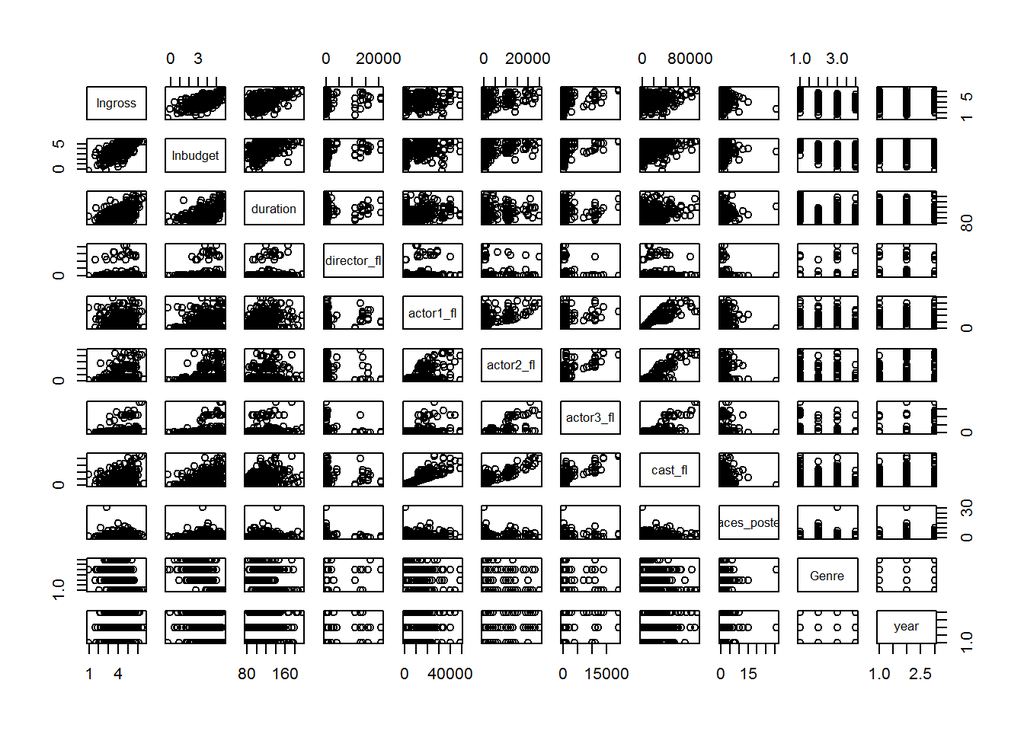

```r
pairs(data1)
```

(fins aqui igual que la classe anterior)

Hem vista abans que entre cast y actor 1 existia multicolinealitat. Ara ens demanen que escollim quin predictorens quedem en el model i quin ens carreguem. Com ho decidim? Quina variable eliminiem, actor1 o cast, per tal de eliminar la multiolinealitat?

Ajustem dos models en els que sabem que no hi ha multicolinealitat perque hem eliminat en cada un una de les dues variables: en un ens quedem amb actor 1 y en l’alte, amb cast

```r
summary(mod<-lm(lngross~lnbudget+duration+actor1_fl+faces_poster+Genre,data1))
```

```
##
## Call:
## lm(formula = lngross ~ lnbudget + duration + actor1_fl + faces_poster +
##     Genre, data = data1)
##
## Residuals:
##     Min      1Q  Median      3Q     Max
## -2.2993 -0.4323  0.0379  0.5521  1.6347
##
## Coefficients:
##                Estimate Std. Error t value Pr(>|t|)
## (Intercept)   1.144e+00  3.157e-01   3.624 0.000338 ***
## lnbudget      4.608e-01  5.211e-02   8.842  < 2e-16 ***
## duration      1.094e-02  2.411e-03   4.540 8.03e-06 ***
## actor1_fl     3.716e-06  3.868e-06   0.961 0.337415
## faces_poster -3.014e-02  1.526e-02  -1.975 0.049140 *
## GenreComedy   2.667e-01  1.325e-01   2.013 0.044965 *
## GenreDrama   -2.001e-01  1.430e-01  -1.399 0.162807
## GenreHorror   1.746e-01  1.677e-01   1.041 0.298663
## ---
## Signif. codes:  0 '***' 0.001 '**' 0.01 '*' 0.05 '.' 0.1 ' ' 1
##
## Residual standard error: 0.6986 on 314 degrees of freedom
## Multiple R-squared:  0.4943, Adjusted R-squared:  0.483
## F-statistic: 43.84 on 7 and 314 DF,  p-value: < 2.2e-16
```

```r
summary(mod<-lm(lngross~lnbudget+duration+cast_fl+faces_poster+Genre,data1))
```

```
##
## Call:
## lm(formula = lngross ~ lnbudget + duration + cast_fl + faces_poster +
##     Genre, data = data1)
##
## Residuals:
##      Min       1Q   Median       3Q      Max
## -2.27429 -0.42875  0.01758  0.46526  1.68644
##
## Coefficients:
##                Estimate Std. Error t value Pr(>|t|)
## (Intercept)   1.169e+00  3.126e-01   3.740 0.000219 ***
## lnbudget      4.427e-01  5.202e-02   8.510 7.26e-16 ***
## duration      1.066e-02  2.389e-03   4.465 1.12e-05 ***
## cast_fl       6.376e-06  2.384e-06   2.674 0.007884 **
## faces_poster -3.370e-02  1.517e-02  -2.222 0.026997 *
## GenreComedy   2.821e-01  1.311e-01   2.152 0.032178 *
## GenreDrama   -1.984e-01  1.415e-01  -1.402 0.161892
## GenreHorror   2.006e-01  1.656e-01   1.211 0.226631
## ---
## Signif. codes:  0 '***' 0.001 '**' 0.01 '*' 0.05 '.' 0.1 ' ' 1
##
## Residual standard error: 0.6918 on 314 degrees of freedom
## Multiple R-squared:  0.5041, Adjusted R-squared:  0.493
## F-statistic: 45.59 on 7 and 314 DF,  p-value: < 2.2e-16
```

Ens quedem amb el swegon, primer per la significació, y segon y mes principalment, perqe el R^2 al primer es 0.49 y al segon: 0.50.

així, eliminem l’actor1 del model.

Mirem tambe el VIF:

```r
vif(mod)
```

```
##                  GVIF Df GVIF^(1/(2*Df))
## lnbudget     2.461498  1        1.568916
## duration     1.680973  1        1.296523
## cast_fl      1.193084  1        1.092284
## faces_poster 1.089065  1        1.043583
## Genre        2.721298  3        1.181579
```

Els VIF em confirmem que no hi ha multicolinealitat.

Estudiem la variable cares als posters.

```r
table(data1$faces_poster)
```

```
##
##   0   1   2   3   4   5   6   7   8  10  12  15  31
## 141  68  51  23  17   2   6   6   3   2   1   1   1
```

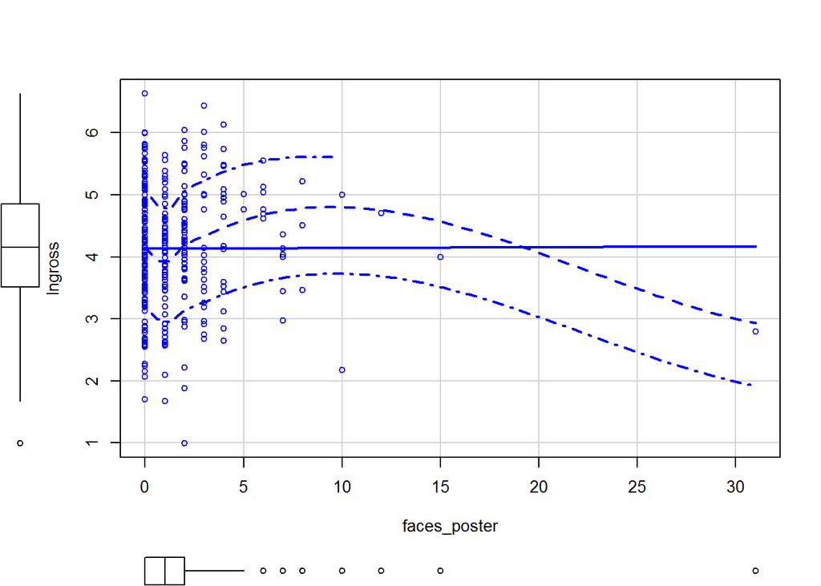

```r
scatterplot(lngross~faces_poster,data1)
```

```r
data1=data1[data1$faces_poster<20,]
nrow(data1)
```

```
## [1] 321
```

com que tenim ua observació contaminant (31 cares), la eliminem. I decidim que nomes hi hagi les que tinguin com a maxim 19 cares en els posters.

si ara tornem a aplicar el scatterplot veurem que les linies no seran tan corbes, el model estara mes ajustat.

De fet, si apliquem el summary d’aquest nou model veiem que el nombre de cares deixa de ser significant un cop eliminada aquella observació tan alta:

```r
summary(mod<-lm(lngross~lnbudget+duration+cast_fl+faces_poster+Genre,data1))
```

```
##
## Call:
## lm(formula = lngross ~ lnbudget + duration + cast_fl + faces_poster +
##     Genre, data = data1)
##
## Residuals:
##      Min       1Q   Median       3Q      Max
## -2.27188 -0.43099  0.01666  0.47360  1.68667
##
## Coefficients:
##                Estimate Std. Error t value Pr(>|t|)
## (Intercept)   1.165e+00  3.131e-01   3.721 0.000235 ***
## lnbudget      4.428e-01  5.209e-02   8.501 7.82e-16 ***
## duration      1.067e-02  2.392e-03   4.461 1.14e-05 ***
## cast_fl       6.192e-06  2.434e-06   2.544 0.011427 *
## faces_poster -2.850e-02  2.016e-02  -1.413 0.158520
## GenreComedy   2.754e-01  1.324e-01   2.080 0.038344 *
## GenreDrama   -1.954e-01  1.419e-01  -1.376 0.169700
## GenreHorror   2.019e-01  1.659e-01   1.217 0.224398
## ---
## Signif. codes:  0 '***' 0.001 '**' 0.01 '*' 0.05 '.' 0.1 ' ' 1
##
## Residual standard error: 0.6928 on 313 degrees of freedom
## Multiple R-squared:  0.5013, Adjusted R-squared:  0.4902
## F-statistic: 44.96 on 7 and 313 DF,  p-value: < 2.2e-16
```

```r
anova(mod)
```

```
## Analysis of Variance Table
##
## Response: lngross
##               Df  Sum Sq Mean Sq  F value    Pr(>F)
## lnbudget       1 135.441 135.441 282.2109 < 2.2e-16 ***
## duration       1   4.884   4.884  10.1761 0.0015669 **
## cast_fl        1   1.549   1.549   3.2285 0.0733306 .
## faces_poster   1   0.100   0.100   0.2094 0.6475649
## Genre          3   9.053   3.018   6.2876 0.0003733 ***
## Residuals    313 150.218   0.480
## ---
## Signif. codes:  0 '***' 0.001 '**' 0.01 '*' 0.05 '.' 0.1 ' ' 1
```

```r
Anova(mod,type=3)
```

```
## Anova Table (Type III tests)
##
## Response: lngross
##               Sum Sq  Df F value    Pr(>F)
## (Intercept)    6.645   1 13.8454 0.0002352 ***
## lnbudget      34.681   1 72.2638 7.816e-16 ***
## duration       9.550   1 19.8993 1.140e-05 ***
## cast_fl        3.107   1  6.4740 0.0114266 *
## faces_poster   0.959   1  1.9978 0.1585196
## Genre          9.053   3  6.2876 0.0003733 ***
## Residuals    150.218 313
## ---
## Signif. codes:  0 '***' 0.001 '**' 0.01 '*' 0.05 '.' 0.1 ' ' 1
```

Així, despres de eliminar la variable correlacionada i la dada contaminant que ha fet que la var deixas de sr significativa, el model final que ens quedem es el següent:

```r
summary(mod<-lm(lngross~lnbudget+duration+cast_fl+Genre,data1))
```

```
##
## Call:
## lm(formula = lngross ~ lnbudget + duration + cast_fl + Genre,
##     data = data1)
##
## Residuals:
##      Min       1Q   Median       3Q      Max
## -2.24261 -0.42384  0.02865  0.50011  1.70529
##
## Coefficients:
##               Estimate Std. Error t value Pr(>|t|)
## (Intercept)  1.174e+00  3.136e-01   3.743 0.000216 ***
## lnbudget     4.430e-01  5.218e-02   8.491 8.29e-16 ***
## duration     1.044e-02  2.390e-03   4.368 1.71e-05 ***
## cast_fl      5.457e-06  2.381e-06   2.292 0.022575 *
## GenreComedy  2.341e-01  1.294e-01   1.810 0.071299 .
## GenreDrama  -1.907e-01  1.421e-01  -1.342 0.180555
## GenreHorror  2.068e-01  1.661e-01   1.245 0.214123
## ---
## Signif. codes:  0 '***' 0.001 '**' 0.01 '*' 0.05 '.' 0.1 ' ' 1
##
## Residual standard error: 0.6939 on 314 degrees of freedom
## Multiple R-squared:  0.4982, Adjusted R-squared:  0.4886
## F-statistic: 51.95 on 6 and 314 DF,  p-value: < 2.2e-16
```

```r
anova(mod)
```

```
## Analysis of Variance Table
##
## Response: lngross
##            Df  Sum Sq Mean Sq  F value    Pr(>F)
## lnbudget    1 135.441 135.441 281.3170 < 2.2e-16 ***
## duration    1   4.884   4.884  10.1438 0.0015932 **
## cast_fl     1   1.549   1.549   3.2183 0.0737821 .
## Genre       3   8.194   2.731   5.6734 0.0008535 ***
## Residuals 314 151.176   0.481
## ---
## Signif. codes:  0 '***' 0.001 '**' 0.01 '*' 0.05 '.' 0.1 ' ' 1
```

```r
Anova(mod,type=3)
```

```
## Anova Table (Type III tests)
##
## Response: lngross
##              Sum Sq  Df F value    Pr(>F)
## (Intercept)   6.744   1 14.0074 0.0002165 ***
## lnbudget     34.711   1 72.0956 8.291e-16 ***
## duration      9.184   1 19.0753 1.709e-05 ***
## cast_fl       2.529   1  5.2526 0.0225755 *
## Genre         8.194   3  5.6734 0.0008535 ***
## Residuals   151.176 314
## ---
## Signif. codes:  0 '***' 0.001 '**' 0.01 '*' 0.05 '.' 0.1 ' ' 1
```

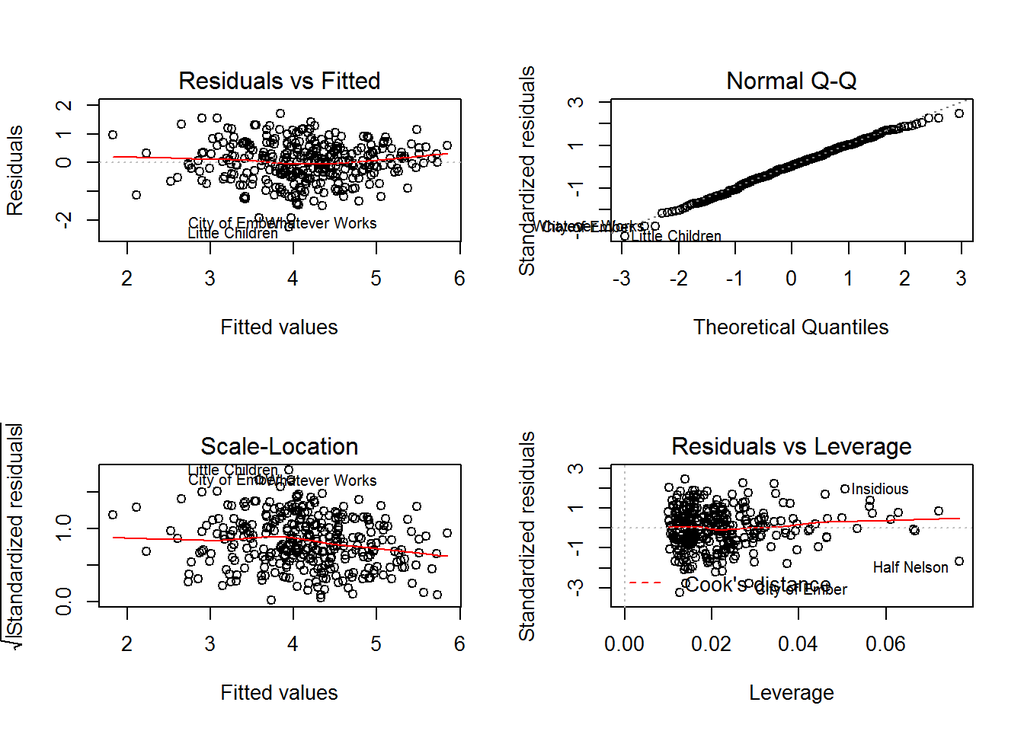

```r
par(mfrow=c(2,2))
plot(mod)
```

```r
par(mfrow=c(1,1))
```

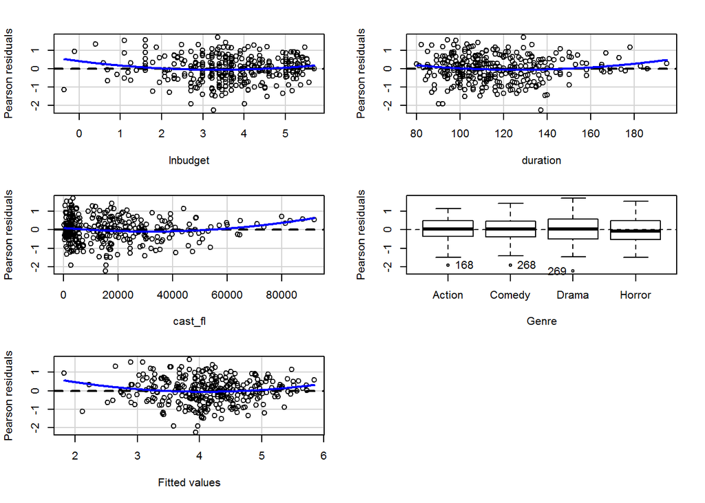

```
##            Test stat Pr(>|Test stat|)
## lnbudget      2.8451         0.004732 **
## duration      1.8946         0.059061 .
## cast_fl       2.4351         0.015445 *
## Genre
## Tukey test    2.9228         0.003469 **
## ---
## Signif. codes:  0 '***' 0.001 '**' 0.01 '*' 0.05 '.' 0.1 ' ' 1
```

```r
residualPlots(mod)
```

Residus no horitzontals, encara podem millorar més el model.

Ara, discutirem si per a les covariables del model val la pena categoritzarla, convertirla a logaritmes o afegir un polinomi:

Si no sabem que hem de fer, femho tot.

PRIMER MODEL: afegim un polinomi de grau dos.

Si elevam budget al 2 ens donara multicolinalitat, si afegim poly, ja s’encarrega de ferho de manera que elimina el problema de la multicolinealitat

```r
summary(mod1a<-lm(lngross~poly(lnbudget,2)+duration+cast_fl+Genre,data1))
```

```
##
## Call:
## lm(formula = lngross ~ poly(lnbudget, 2) + duration + cast_fl +
##     Genre, data = data1)
##
## Residuals:
##     Min      1Q  Median      3Q     Max
## -2.1454 -0.4116  0.0145  0.4362  1.7632
##
## Coefficients:
##                     Estimate Std. Error t value Pr(>|t|)
## (Intercept)        2.789e+00  2.927e-01   9.531  < 2e-16 ***
## poly(lnbudget, 2)1 1.120e+01  1.278e+00   8.766  < 2e-16 ***
## poly(lnbudget, 2)2 2.703e+00  9.501e-01   2.845 0.004732 **
## duration           8.640e-03  2.447e-03   3.532 0.000475 ***
## cast_fl            4.180e-06  2.397e-06   1.744 0.082181 .
## GenreComedy        5.213e-01  1.629e-01   3.199 0.001520 **
## GenreDrama         1.311e-01  1.804e-01   0.727 0.467926
## GenreHorror        4.910e-01  1.922e-01   2.554 0.011126 *
## ---
## Signif. codes:  0 '***' 0.001 '**' 0.01 '*' 0.05 '.' 0.1 ' ' 1
##
## Residual standard error: 0.6862 on 313 degrees of freedom
## Multiple R-squared:  0.5108, Adjusted R-squared:  0.4999
## F-statistic: 46.69 on 7 and 313 DF,  p-value: < 2.2e-16
```

poly(lnbudget, 2)2 no es es logaritme al quadrat, es una transofrmació al quadrat igual que poly(lnbudget, 2)1 no és exactament el terme lineal. Però dona igual, no cal etrar en això.

Lo important és la interpretació: vegem que ambdós son significatius. Tant el terme quadrat com el nileal, també el R^2 i la significació global es millor.

També ho confirmem amb l’anova 3.

```r
anova(mod1a)
```

```
## Analysis of Variance Table
##
## Response: lngross
##                    Df  Sum Sq Mean Sq  F value    Pr(>F)
## poly(lnbudget, 2)   2 139.686  69.843 148.3451 < 2.2e-16 ***
## duration            1   3.163   3.163   6.7183 0.0099905 **
## cast_fl             1   1.030   1.030   2.1882 0.1400815
## Genre               3  10.000   3.333   7.0802 0.0001285 ***
## Residuals         313 147.365   0.471
## ---
## Signif. codes:  0 '***' 0.001 '**' 0.01 '*' 0.05 '.' 0.1 ' ' 1
```

```r
Anova(mod1a,type=3)
```

```
## Anova Table (Type III tests)
##
## Response: lngross
##                    Sum Sq  Df F value    Pr(>F)
## (Intercept)        42.772   1 90.8469 < 2.2e-16 ***
## poly(lnbudget, 2)  38.522   2 40.9097 < 2.2e-16 ***
## duration            5.872   1 12.4725 0.0004751 ***
## cast_fl             1.432   1  3.0407 0.0821811 .
## Genre              10.000   3  7.0802 0.0001285 ***
## Residuals         147.365 313
## ---
## Signif. codes:  0 '***' 0.001 '**' 0.01 '*' 0.05 '.' 0.1 ' ' 1
```

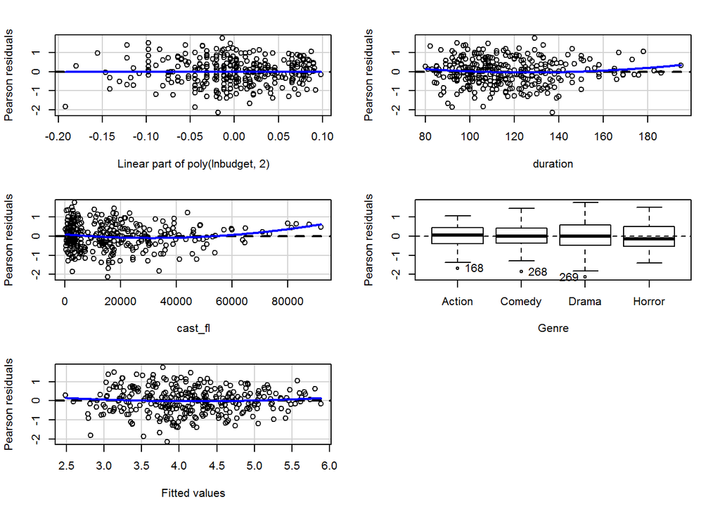

```
##                   Test stat Pr(>|Test stat|)
## poly(lnbudget, 2)
## duration             1.4174          0.15736
## cast_fl              2.4156          0.01628 *
## Genre
## Tukey test           1.5442          0.12255
## ---
## Signif. codes:  0 '***' 0.001 '**' 0.01 '*' 0.05 '.' 0.1 ' ' 1
```

```r
residualPlots(mod1a)
```

```r
shapiro.test(resid(mod1a))
```

```
##
##  Shapiro-Wilk normality test
##
## data:  resid(mod1a)
## W = 0.99619, p-value = 0.6374
```

```r
shapiro.test(rstudent(mod1a))
```

```
##
##  Shapiro-Wilk normality test
##
## data:  rstudent(mod1a)
## W = 0.99567, p-value = 0.5198
```

```r
par(mfrow=c(1,2))
qqPlot(resid(mod1a))
```

```
## Little Children   Whatever Works
##              269              268
```

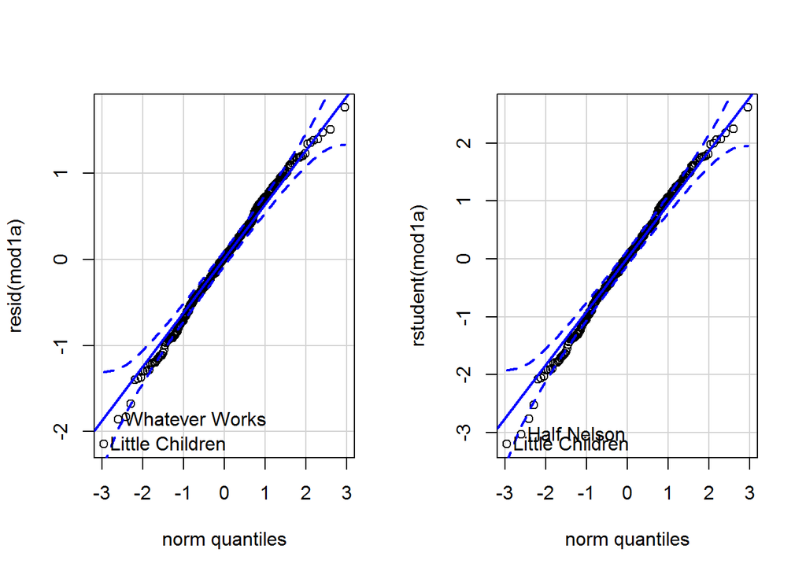

```
## Little Children      Half Nelson
##              269              320
```

```r
qqPlot(rstudent(mod1a))
```

```r
par(mfrow=c(1,1))
```

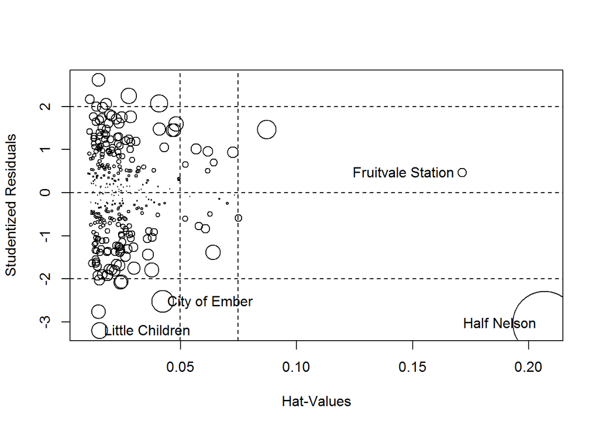

```
##                       StudRes        Hat       CookD
## City of Ember      -2.5230385 0.04244692 0.034678406
## Little Children    -3.1966235 0.01510675 0.019031317
## Fruitvale Station   0.4628707 0.17139322 0.005553492
## Half Nelson        -3.0298120 0.20679610 0.291537902
```

```r
influencePlot(mod1a)
```

```r
outlierTest(mod1a)
```

```
## No Studentized residuals with Bonferonni p < 0.05
## Largest |rstudent|:
##                   rstudent unadjusted p-value Bonferonni p
## Little Children  -3.196624           0.001533      0.49208
```

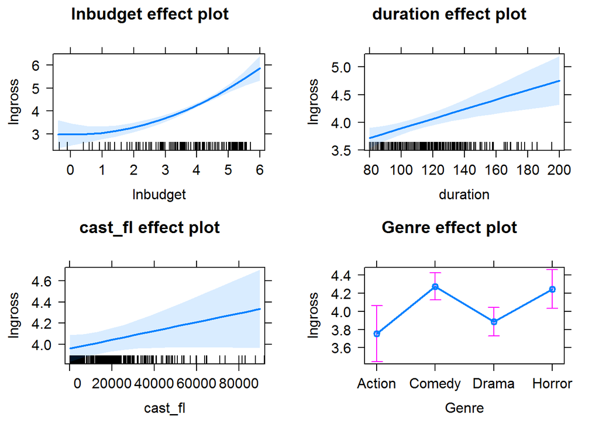

```r
plot(allEffects(mod1a))
```

```r
summary(data1$budget)
```

```
## Length  Class   Mode
##      0   NULL   NULL
```

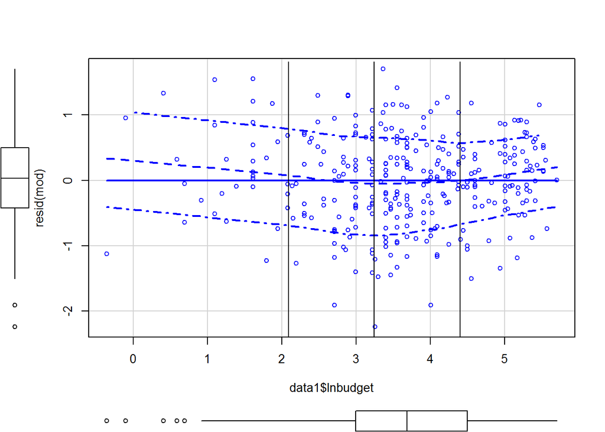

```r
scatterplot(resid(mod)~data1$lnbudget)
abline(v=c(log(10),log(30),log(90)))
```

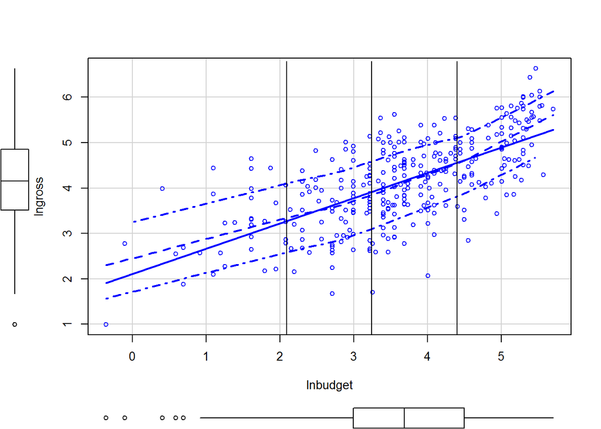

```r
scatterplot(lngross~lnbudget,data1)
abline(v=c(log(10),log(30),log(90)))
```

```r
data1$lnbudgetCat=cut(data1$lnbudget,c(-999,log(10),log(30),log(90),999),labels=c("<10","10-30","30-90",">90"))
summary(data1$lnbudgetCat)
```

```
##   <10 10-30 30-90   >90
##    43    89   111    78
```

Els scatterplots son els residus enftonr a les variable explicativa lnbudget. Amb les línies, es defineixen 4 grups. Així, extendrem el model el model amb una var categorica a 4 nivells per veure si podem millorar l’ajust i convertir la distribucio dels residus a lineal.

Tenir en compte qe gastarem 3 variables mes que haurem d’afegir.

Peruè aquests límits? és una mica anar jugant. S’ha d’anar mirant de separar els punts de tall seegons si la recta esta per sota per sobre o damunt de la recta ideal. I veure si amb mes o menys categories i quins punts ens dona un ajust millor.

```r
summary(mod1b<-lm(lngross~lnbudgetCat+duration+cast_fl+Genre,data1))
```

```
##
## Call:
## lm(formula = lngross ~ lnbudgetCat + duration + cast_fl + Genre,
##     data = data1)
##
## Residuals:
##      Min       1Q   Median       3Q      Max
## -2.09777 -0.48793  0.04761  0.47946  1.93378
##
## Coefficients:
##                    Estimate Std. Error t value Pr(>|t|)
## (Intercept)       1.764e+00  3.071e-01   5.743 2.21e-08 ***
## lnbudgetCat10-30  4.143e-01  1.358e-01   3.050  0.00248 **
## lnbudgetCat30-90  8.104e-01  1.411e-01   5.744 2.19e-08 ***
## lnbudgetCat>90    1.495e+00  2.126e-01   7.029 1.31e-11 ***
## duration          1.224e-02  2.392e-03   5.117 5.44e-07 ***
## cast_fl           5.728e-06  2.443e-06   2.345  0.01965 *
## GenreComedy       3.566e-01  1.702e-01   2.096  0.03693 *
## GenreDrama       -1.651e-01  1.752e-01  -0.943  0.34659
## GenreHorror       2.595e-01  1.918e-01   1.353  0.17693
## ---
## Signif. codes:  0 '***' 0.001 '**' 0.01 '*' 0.05 '.' 0.1 ' ' 1
##
## Residual standard error: 0.7099 on 312 degrees of freedom
## Multiple R-squared:  0.4781, Adjusted R-squared:  0.4647
## F-statistic: 35.72 on 8 and 312 DF,  p-value: < 2.2e-16
```

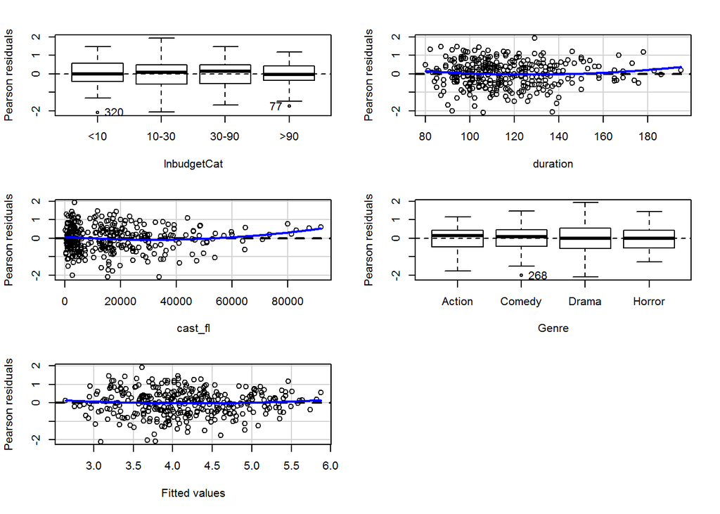

```
##             Test stat Pr(>|Test stat|)
## lnbudgetCat
## duration       1.4523          0.14744
## cast_fl        1.9635          0.05048 .
## Genre
## Tukey test     1.3709          0.17042
## ---
## Signif. codes:  0 '***' 0.001 '**' 0.01 '*' 0.05 '.' 0.1 ' ' 1
```

```r
residualPlots(mod1b)
```

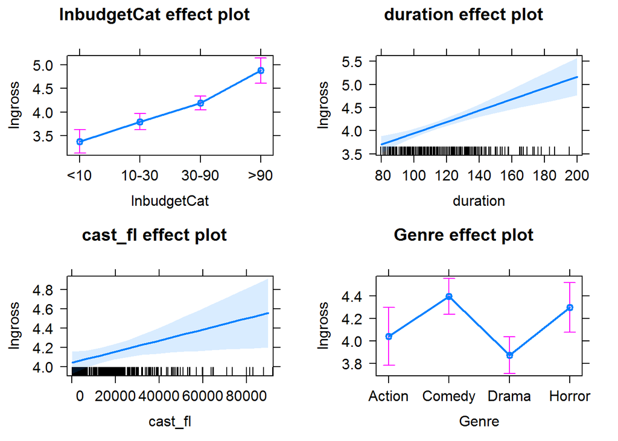

```r
plot(allEffects(mod1b))
```

El model també queda validat

Ara cal rspondre, quins ens quedem, el del polinomi o el de les categories?

Els comparem

```r
anova(mod,mod1a)
```

```
## Analysis of Variance Table
##
## Model 1: lngross ~ lnbudget + duration + cast_fl + Genre
## Model 2: lngross ~ poly(lnbudget, 2) + duration + cast_fl + Genre
##   Res.Df    RSS Df Sum of Sq      F   Pr(>F)
## 1    314 151.18
## 2    313 147.37  1    3.8112 8.0949 0.004732 **
## ---
## Signif. codes:  0 '***' 0.001 '**' 0.01 '*' 0.05 '.' 0.1 ' ' 1
```

```r
anova(mod,mod1b)
```

```
## Analysis of Variance Table
##
## Model 1: lngross ~ lnbudget + duration + cast_fl + Genre
## Model 2: lngross ~ lnbudgetCat + duration + cast_fl + Genre
##   Res.Df    RSS Df Sum of Sq F Pr(>F)
## 1    314 151.18
## 2    312 157.23  2   -6.0528
```

```r
AIC(mod,mod1a,mod1b)
```

```
##       df      AIC
## mod    8 685.2476
## mod1a  9 679.0514
## mod1b 10 701.8492
```

```r
BIC(mod,mod1a,mod1b)
```

```
##       df      BIC
## mod    8 715.4192
## mod1a  9 712.9944
## mod1b 10 739.5636
```

```r
mod1=mod1a
```

CONCLUSIÓ:

Ens quedem amb el del terme quadrpàtic.

Mateix que lo anterior però am la variable cast:

```r
data1$lncast_fl=log(data1$cast_fl+1)
summary(mod2a<-lm(lngross~poly(lnbudget,2)+duration+lncast_fl+Genre,data1))
```

```
##
## Call:
## lm(formula = lngross ~ poly(lnbudget, 2) + duration + lncast_fl +
##     Genre, data = data1)
##
## Residuals:
##      Min       1Q   Median       3Q      Max
## -2.16022 -0.44127  0.01533  0.50394  1.72070
##
## Coefficients:
##                     Estimate Std. Error t value Pr(>|t|)
## (Intercept)         2.693456   0.412932   6.523 2.77e-10 ***
## poly(lnbudget, 2)1 11.583672   1.294325   8.950  < 2e-16 ***
## poly(lnbudget, 2)2  2.972525   0.941635   3.157 0.001751 **
## duration            0.008771   0.002457   3.570 0.000413 ***
## lncast_fl           0.015319   0.032742   0.468 0.640191
## GenreComedy         0.537546   0.163623   3.285 0.001134 **
## GenreDrama          0.159133   0.181659   0.876 0.381704
## GenreHorror         0.492576   0.193116   2.551 0.011227 *
## ---
## Signif. codes:  0 '***' 0.001 '**' 0.01 '*' 0.05 '.' 0.1 ' ' 1
##
## Residual standard error: 0.6892 on 313 degrees of freedom
## Multiple R-squared:  0.5064, Adjusted R-squared:  0.4954
## F-statistic: 45.87 on 7 and 313 DF,  p-value: < 2.2e-16
```

```r
summary(mod2b<-lm(lngross~poly(lnbudget,2)+duration+poly(cast_fl,2)+Genre,data1))
```

```
##
## Call:
## lm(formula = lngross ~ poly(lnbudget, 2) + duration + poly(cast_fl,
##     2) + Genre, data = data1)
##
## Residuals:
##      Min       1Q   Median       3Q      Max
## -2.10603 -0.42683  0.03207  0.45546  1.69231
##
## Coefficients:
##                     Estimate Std. Error t value Pr(>|t|)
## (Intercept)         2.866751   0.290121   9.881  < 2e-16 ***
## poly(lnbudget, 2)1 11.447409   1.272378   8.997  < 2e-16 ***
## poly(lnbudget, 2)2  2.666044   0.943021   2.827 0.005000 **
## duration            0.008415   0.002430   3.463 0.000608 ***
## poly(cast_fl, 2)1   1.282254   0.753003   1.703 0.089591 .
## poly(cast_fl, 2)2   1.672903   0.692546   2.416 0.016284 *
## GenreComedy         0.550024   0.162135   3.392 0.000782 ***
## GenreDrama          0.171339   0.179822   0.953 0.341416
## GenreHorror         0.493638   0.190779   2.587 0.010120 *
## ---
## Signif. codes:  0 '***' 0.001 '**' 0.01 '*' 0.05 '.' 0.1 ' ' 1
##
## Residual standard error: 0.6809 on 312 degrees of freedom
## Multiple R-squared:  0.5198, Adjusted R-squared:  0.5075
## F-statistic: 42.22 on 8 and 312 DF,  p-value: < 2.2e-16
```

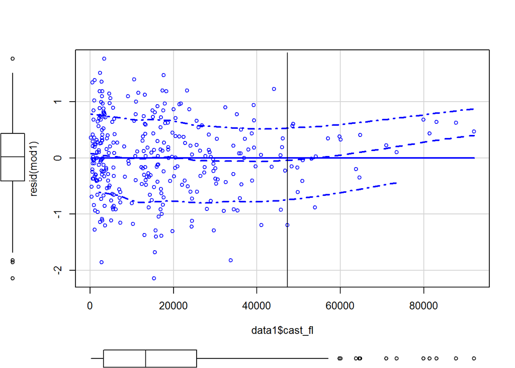

```r
scatterplot(resid(mod1)~data1$cast_fl)
abline(v=50000)
```

```r
data1$cast_flCat=cut(data1$cast_fl,c(-999,50000,999999),labels=c("<15k",">50k"))
summary(data1$cast_flCat)
```

```
## <15k >50k
##  303   18
```

```r
summary(mod2c<-lm(lngross~poly(lnbudget,2)+duration+cast_flCat+Genre,data1))
```

```
##
## Call:
## lm(formula = lngross ~ poly(lnbudget, 2) + duration + cast_flCat +
##     Genre, data = data1)
##
## Residuals:
##      Min       1Q   Median       3Q      Max
## -2.13451 -0.42264  0.03461  0.46665  1.72624
##
## Coefficients:
##                     Estimate Std. Error t value Pr(>|t|)
## (Intercept)         2.788608   0.291610   9.563  < 2e-16 ***
## poly(lnbudget, 2)1 11.331682   1.251024   9.058  < 2e-16 ***
## poly(lnbudget, 2)2  2.799060   0.936222   2.990 0.003014 **
## duration            0.008980   0.002442   3.678 0.000277 ***
## cast_flCat>50k      0.373100   0.172657   2.161 0.031459 *
## GenreComedy         0.549295   0.162065   3.389 0.000790 ***
## GenreDrama          0.145097   0.178896   0.811 0.417944
## GenreHorror         0.493388   0.191744   2.573 0.010537 *
## ---
## Signif. codes:  0 '***' 0.001 '**' 0.01 '*' 0.05 '.' 0.1 ' ' 1
##
## Residual standard error: 0.6844 on 313 degrees of freedom
## Multiple R-squared:  0.5133, Adjusted R-squared:  0.5024
## F-statistic: 47.16 on 7 and 313 DF,  p-value: < 2.2e-16
```

```r
anova(mod1,mod2a)
```

```
## Analysis of Variance Table
##
## Model 1: lngross ~ poly(lnbudget, 2) + duration + cast_fl + Genre
## Model 2: lngross ~ poly(lnbudget, 2) + duration + lncast_fl + Genre
##   Res.Df    RSS Df Sum of Sq F Pr(>F)
## 1    313 147.37
## 2    313 148.69  0   -1.3276
```

```r
anova(mod1,mod2b)
```

```
## Analysis of Variance Table
##
## Model 1: lngross ~ poly(lnbudget, 2) + duration + cast_fl + Genre
## Model 2: lngross ~ poly(lnbudget, 2) + duration + poly(cast_fl, 2) + Genre
##   Res.Df    RSS Df Sum of Sq     F  Pr(>F)
## 1    313 147.37
## 2    312 144.66  1    2.7054 5.835 0.01628 *
## ---
## Signif. codes:  0 '***' 0.001 '**' 0.01 '*' 0.05 '.' 0.1 ' ' 1
```

```r
anova(mod1,mod2c)
```

```
## Analysis of Variance Table
##
## Model 1: lngross ~ poly(lnbudget, 2) + duration + cast_fl + Genre
## Model 2: lngross ~ poly(lnbudget, 2) + duration + cast_flCat + Genre
##   Res.Df    RSS Df Sum of Sq F Pr(>F)
## 1    313 147.37
## 2    313 146.61  0   0.75563
```

```r
AIC(mod1,mod2a,mod2b,mod2c)
```

```
##       df      AIC
## mod1   9 679.0514
## mod2a  9 681.9304
## mod2b 10 675.1035
## mod2c  9 677.4012
```

```r
BIC(mod1,mod2a,mod2b,mod2c)
```

```
##       df      BIC
## mod1   9 712.9944
## mod2a  9 715.8733
## mod2b 10 712.8179
## mod2c  9 711.3442
```

```r
mod2=mod2b
```

```r
anova(mod2)
```

```
## Analysis of Variance Table
##
## Response: lngross
##                    Df  Sum Sq Mean Sq  F value    Pr(>F)
## poly(lnbudget, 2)   2 139.686  69.843 150.6367 < 2.2e-16 ***
## duration            1   3.163   3.163   6.8220 0.0094394 **
## poly(cast_fl, 2)    2   3.926   1.963   4.2342 0.0153323 *
## Genre               3   9.810   3.270   7.0524 0.0001335 ***
## Residuals         312 144.660   0.464
## ---
## Signif. codes:  0 '***' 0.001 '**' 0.01 '*' 0.05 '.' 0.1 ' ' 1
```

```r
Anova(mod2,type=3)
```

```
## Anova Table (Type III tests)
##
## Response: lngross
##                    Sum Sq  Df F value    Pr(>F)
## (Intercept)        45.271   1 97.6388 < 2.2e-16 ***
## poly(lnbudget, 2)  40.120   2 43.2648 < 2.2e-16 ***
## duration            5.562   1 11.9952 0.0006079 ***
## poly(cast_fl, 2)    4.137   2  4.4614 0.0122925 *
## Genre               9.810   3  7.0524 0.0001335 ***
## Residuals         144.660 312
## ---
## Signif. codes:  0 '***' 0.001 '**' 0.01 '*' 0.05 '.' 0.1 ' ' 1
```

```r
vif(mod2)
```

```
##                       GVIF Df GVIF^(1/(2*Df))
## poly(lnbudget, 2) 4.772984  2        1.478078
## duration          1.785470  1        1.336215
## poly(cast_fl, 2)  1.264411  2        1.060406
## Genre             4.597506  3        1.289497
```

```r
anova(mod1,mod2)
```

```
## Analysis of Variance Table
##
## Model 1: lngross ~ poly(lnbudget, 2) + duration + cast_fl + Genre
## Model 2: lngross ~ poly(lnbudget, 2) + duration + poly(cast_fl, 2) + Genre
##   Res.Df    RSS Df Sum of Sq     F  Pr(>F)
## 1    313 147.37
## 2    312 144.66  1    2.7054 5.835 0.01628 *
## ---
## Signif. codes:  0 '***' 0.001 '**' 0.01 '*' 0.05 '.' 0.1 ' ' 1
```

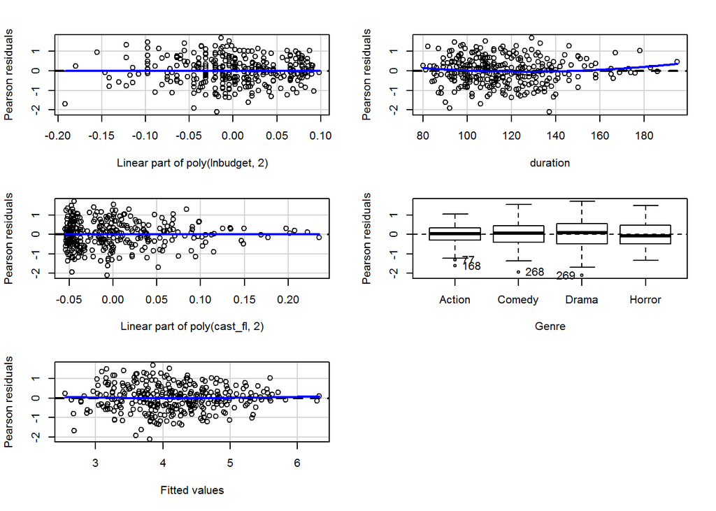

```
##                   Test stat Pr(>|Test stat|)
## poly(lnbudget, 2)
## duration             1.4595           0.1454
## poly(cast_fl, 2)
## Genre
## Tukey test           0.6898           0.4903
```

```r
residualPlots(mod2)
```

```r
shapiro.test(resid(mod2))
```

```
##
##  Shapiro-Wilk normality test
##
## data:  resid(mod2)
## W = 0.99582, p-value = 0.5517
```

```r
shapiro.test(rstudent(mod2))
```

```
##
##  Shapiro-Wilk normality test
##
## data:  rstudent(mod2)
## W = 0.99535, p-value = 0.4534
```

```r
par(mfrow=c(1,2))
qqPlot(resid(mod2))
```

```
## Little Children   Whatever Works
##              269              268
```

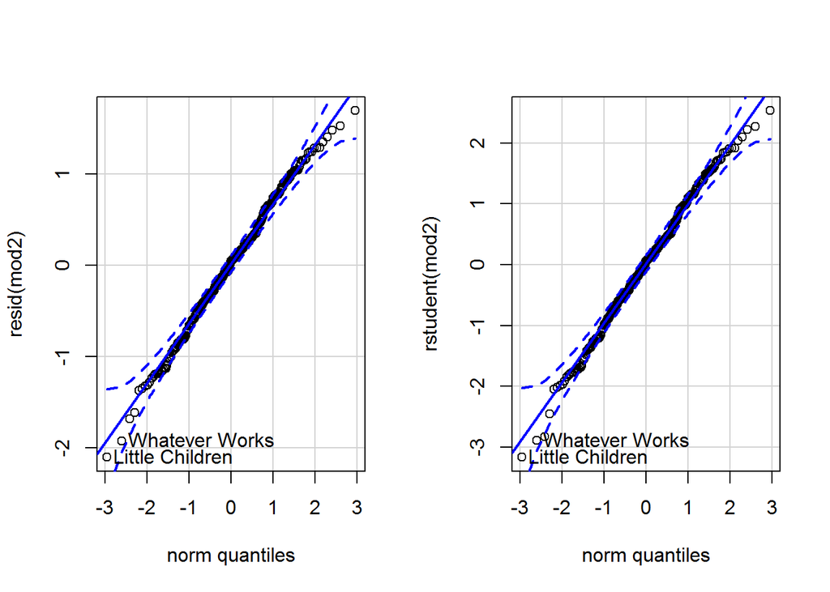

```
## Little Children   Whatever Works
##              269              268
```

```r
qqPlot(rstudent(mod2))
```

```r
par(mfrow=c(1,1))
```

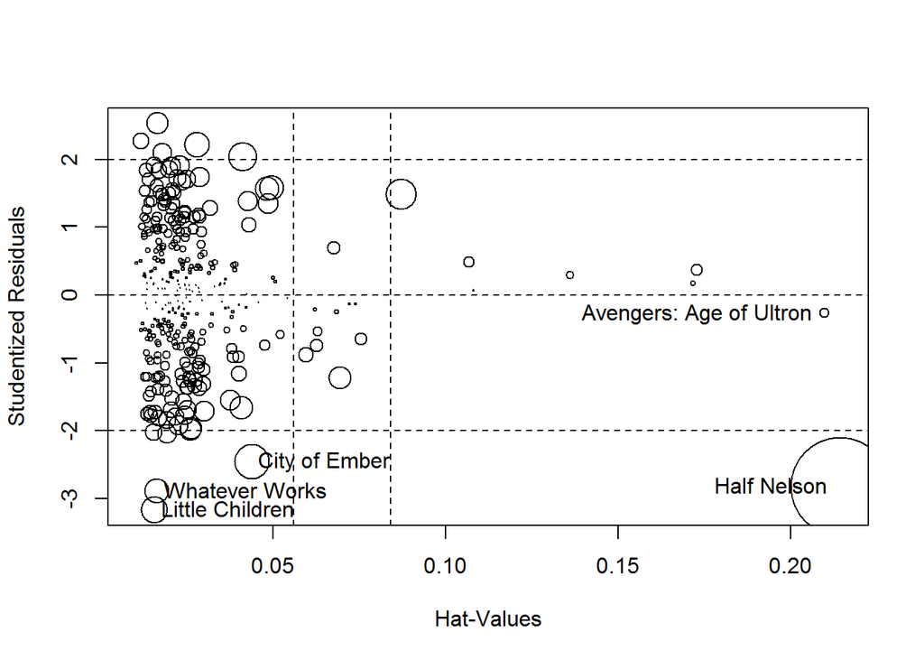

```
##                             StudRes        Hat       CookD
## Avengers: Age of Ultron  -0.2665877 0.20978260 0.002102595
## City of Ember            -2.4494729 0.04385541 0.030095237
## Whatever Works           -2.8869160 0.01650441 0.015183169
## Little Children          -3.1620926 0.01567962 0.017201128
## Half Nelson              -2.8240654 0.21424769 0.236338756
```

```r
influencePlot(mod2)
```

```r
outlierTest(mod2)
```

```
## No Studentized residuals with Bonferonni p < 0.05
## Largest |rstudent|:
##                   rstudent unadjusted p-value Bonferonni p
## Little Children  -3.162093          0.0017209      0.55241
```

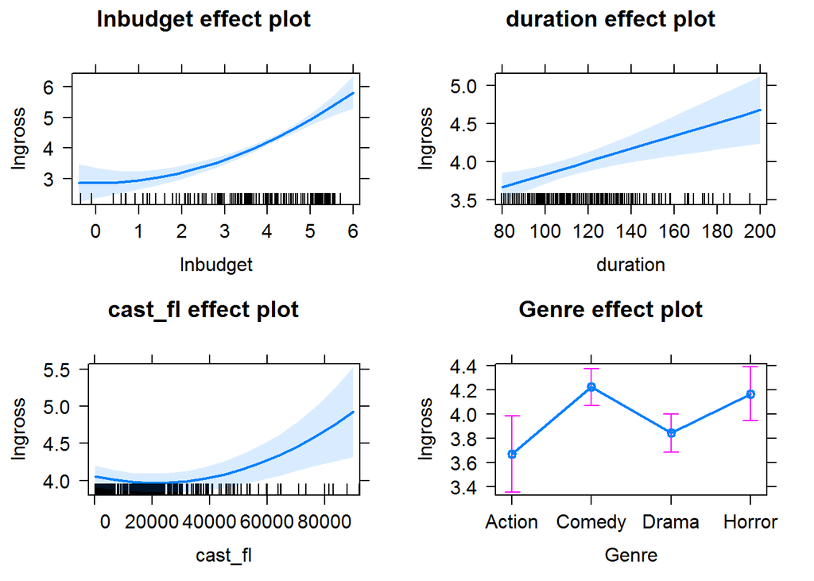

```r
plot(allEffects(mod2))
```

```r
pr<-predict(mod2,newdata=data.frame(lnbudget=log(20),duration=90,year="2013-2016",director_fl=0,actor1_fl=0,actor2_fl=0,cast_fl=0,faces_poster=1,Genre="Horror"),interval="confidence")
exp(pr)
```

```
##        fit      lwr     upr
## 1 39.62915 31.59815 49.7013
```

```r
pr2<-predict(mod2,newdata=data.frame(lnbudget=log(20),duration=90,year="2013-2016",director_fl=0,actor1_fl=0,actor2_fl=0,cast_fl=0,faces_poster=1,Genre="Horror"),interval="prediction")
exp(pr2)
```

```
##        fit      lwr     upr
## 1 39.62915 10.18363 154.215
```